# MSBP - Data Cleaning, Summary, and Visualizations

Charlie Whittaker

2/16/2026

```r
library(openxlsx)
library(tidyverse)
library(ggrepel)
library(ggpubr)
library(purrr)
library(knitr)
library(lubridate)
library(patchwork)
```

# Data Import

## Read in ilabs stock data and select Biopolymers rows

```r
ilabs <- read.xlsx("../data/stock_ilabs.xlsx")
ilabs.msbp <- ilabs %>% dplyr::filter(Core.Name == "Biopolymers & Proteomics Core")
rm(ilabs)
```

### Repair date

```r
ilabs.msbp$Purchase.Date <- as.Date(ilabs.msbp$Purchase.Date, origin = "1899-12-30")
```

## Read in METPRO invoice data

```r
metpro24 <- read.xlsx("../data/METPRO_2024_Core Charges by Service.xlsx")
metpro25 <- read.xlsx("../data/METPRO2025_Core Charges by Service.xlsx")
```

### Combine data files

```r
metpro <- rbind(metpro24,metpro25)
```

# Export metpro faculty/lab data and manually update annotations

This has already been done but will need to be repeated when new data are incorporated.

```r
# metpro.lab.data <- metpro %>% dplyr::select(lab_name)
# metpro.lab.data.distinct <- metpro.lab.data %>% dplyr::distinct()
# write.xlsx(metpro.lab.data.distinct,"../data/metpro.lab.data.distinct.xlsx")
```

# Data Repair - metpro

## simplify the metpro dataframe

This first step identifies empty or near-empty columns and summarizes the results. The metpro data as none of these low complexity columns.

```r
# simple.cols <- map_df(names(metpro), ~{
#   col <- metpro[[.]]
#   n_unique <- n_distinct(col[!is.na(col)])
#
#   tibble(
#     column = .,
#     value = if_else(all(is.na(col)),
#                     "empty",
#                     if_else(n_unique == 1,
#                            as.character(unique(col[!is.na(col)])[1]),
#                            NA_character_))
#   )
# }) %>%
#   filter(!is.na(value))
#
# kable(simple.cols, format = "simple")
```

If the data frame had these columns, they could be excluded with this code.

```r
# cat("Dimensions before simple column exclusion:", dim(metpro), "\n")
# metpro <- metpro %>% dplyr::select(-all_of(simple.cols$column))
# cat("Dimensions after simple column exclusion:", dim(metpro), "\n")
```

# Examination of metabolomics dataframes

Summarize the number of unique values per column.

```r
unique_counts <- sapply(metpro, function(x) length(unique(x)))

data.frame(
  Column = names(unique_counts),
  Unique_Values = as.numeric(unique_counts),
  row.names = NULL
) %>%
  arrange(desc(Unique_Values)) %>%
  knitr::kable()
```

| Column | Unique_Values |
| --- | --- |
| service_date | 302 |
| amount | 197 |
| qty | 105 |
| person_name | 61 |
| service_name | 39 |
| lab_name | 31 |
| customer_number | 31 |
| po_number | 30 |
| unit_price | 15 |
| inst_name | 14 |
| status | 10 |

## Compare column names in ilabs.msbp and metpro

```r
colnames(ilabs.msbp)
```

```
 [1] "Service.ID"          "Service.Type"        "Customer.Name"       "Customer.Lab"        "Customer.Department" "Customer.Institute"
 [7] "Charge.Name"         "Notes"               "Unit.of.Measure"     "Quantity"            "Price"               "Total.Price"
[13] "Price.Type"          "Purchase.Date"       "Core.Name"           "Center"              "Category"            "Usage.Type"
```

```r
colnames(metpro)
```

```
 [1] "person_name"     "inst_name"       "lab_name"        "customer_number" "po_number"       "status"          "service_date"    "service_name"
 [9] "qty"             "unit_price"      "amount"
```

### Repair the metpro date

The imported dates are in a machine-readable format that is not valuable. convert to human readable:

```r
metpro$service_date <- as.Date(metpro$service_date, origin = "1899-12-30")
```

### Rename columns to match ilabs

```r
metpro <- metpro %>% dplyr::rename(Customer.Name = person_name)
metpro <- metpro %>% dplyr::rename(Customer.Institute = inst_name)
metpro <- metpro %>% dplyr::rename(Customer.Lab = lab_name)
metpro <- metpro %>% dplyr::rename(Purchase.Date = service_date)
metpro <- metpro %>% dplyr::rename(Charge.Name = service_name)
metpro <- metpro %>% dplyr::rename(Quantity = qty)
metpro <- metpro %>% dplyr::rename(Price = unit_price)
metpro <- metpro %>% dplyr::rename(Total.Price= amount)
```

### Add missing columns needed to match ilabs data

```r
metpro <- metpro %>% dplyr::mutate(Service.ID = "metpro")
metpro <- metpro %>% dplyr::mutate(Service.Type = "ToUpdate")
metpro <- metpro %>% dplyr::mutate(Customer.Department = "")
metpro <- metpro %>% dplyr::mutate(Unit.of.Measure = "ToUpdate")
metpro <- metpro %>% dplyr::mutate(Price.Type = "")
metpro <- metpro %>% dplyr::mutate(Core.Name = "metpro")
metpro <- metpro %>% dplyr::mutate(Center = "")
metpro <- metpro %>% dplyr::mutate(Usage.Type = "")
metpro <- metpro %>% dplyr::mutate(Notes = "")
metpro <- metpro %>% dplyr::mutate(Category = "")
```

### Select ilabs columns from metpro

```r
metpro.to_rbind <- metpro %>%
  dplyr::select(Service.ID, Service.Type, Customer.Name, Customer.Lab, Customer.Department,
                Customer.Institute, Charge.Name, Notes, Unit.of.Measure, Quantity, Price,
                Total.Price, Price.Type, Purchase.Date, Core.Name, Center, Category,
                Usage.Type)
```

# Join ilabs and WI metabolomics

```r
msbp.final <- rbind(ilabs.msbp,metpro.to_rbind)
```

## Remove problematic rows identified by SF (Polizzi and 2 NA rows identified by CAW)

Find the rows:

```r
msbp.final %>% dplyr::filter(is.na(Customer.Lab) | Customer.Lab == "Polizzi Lab")
```

| Service.ID | Service.Type | Customer.Name | Customer.Lab | Customer.Department | Customer.Institute | Charge.Name | Notes | Unit.of.Measure | Quantity | Price | Total.Price | Price.Type | Purchase.Date | Core.Name | Center | Category | Usage.Type |
| --- | --- | --- | --- | --- | --- | --- | --- | --- | --- | --- | --- | --- | --- | --- | --- | --- | --- |
| metpro | ToUpdate | 46036 | NA |  | NA | NA |  | ToUpdate | 0.3346643 | NA | NA |  |  | metpro |  |  |  |
| metpro | ToUpdate | Jean Smith | Polizzi Lab |  | Kusama Foundation for Infinite Spaces | 2021 Targeted Metabolomics Fee per sample (Polar) |  | ToUpdate | 1.0000000 | 70 | 70 |  | 2025-02-12 | metpro |  |  |  |
| metpro | ToUpdate | Jean Smith | Polizzi Lab |  | Kusama Foundation for Infinite Spaces | Method Development and Data Analysis Time (Polar) |  | ToUpdate | 1.0000000 | 60 | 60 |  | 2025-02-12 | metpro |  |  |  |
| metpro | ToUpdate | 46036 | NA |  | NA | NA |  | ToUpdate | 0.3351620 | NA | NA |  |  | metpro |  |  |  |

Remove them from the data frame:

```r
cat("Dimensions before NA and Polizzi exclusion:", dim(msbp.final), "\n")
```

```
Dimensions before NA and Polizzi exclusion: 6689 18
```

```r
msbp.final <- msbp.final %>% dplyr::filter(!is.na(Customer.Lab) & Customer.Lab != "Polizzi Lab")
cat("Dimensions after NA and Polizzi exclusion:", dim(msbp.final), "\n")
```

```
Dimensions after NA and Polizzi exclusion: 6685 18
```

### Check dates before reporting range selection

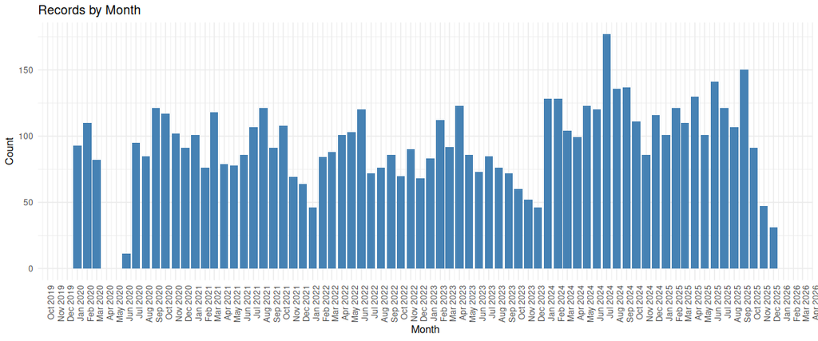

```r
msbp.final %>%
  mutate(Year_Month = floor_date(Purchase.Date, "month")) %>%
  count(Year_Month) %>%
  arrange(Year_Month) %>%
  ggplot(aes(x = Year_Month, y = n)) +
  geom_col(fill = "steelblue") +
  scale_x_date(date_labels = "%b %Y", date_breaks = "1 month") +
  labs(title = "Records by Month",
       x = "Month",
       y = "Count") +
  theme_minimal() +
  theme(axis.text.x = element_text(angle = 90, hjust = 1))
```

### Select reporting date range

```r
cat("Dimensions of ilabs.flow before reporting range selection:", dim(msbp.final), "\n")
```

```
Dimensions of ilabs.flow before reporting range selection: 6685 18
```

```r
msbp.final <- msbp.final %>% dplyr::filter(between(Purchase.Date, as.Date("2020-05-01"), as.Date("2025-10-31")))
cat("Dimensions of ilabs.flow after reporting range selection:", dim(msbp.final), "\n")
```

```
Dimensions of ilabs.flow after reporting range selection: 6320 18
```

### Check dates after reporting range selection

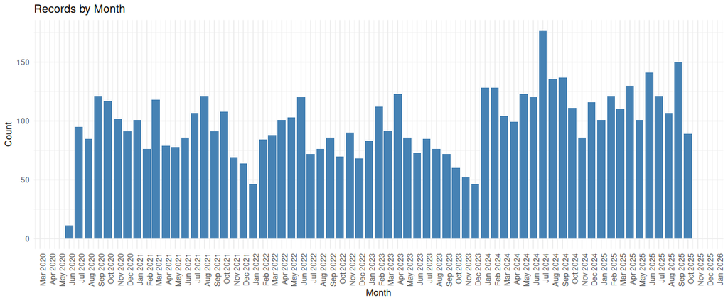

```r
msbp.final %>%
  mutate(Year_Month = floor_date(Purchase.Date, "month")) %>%
  count(Year_Month) %>%
  arrange(Year_Month) %>%
  ggplot(aes(x = Year_Month, y = n)) +
  geom_col(fill = "steelblue") +
  scale_x_date(date_labels = "%b %Y", date_breaks = "1 month") +
  labs(title = "Records by Month",
       x = "Month",
       y = "Count") +
  theme_minimal() +
  theme(axis.text.x = element_text(angle = 90, hjust = 1))
```

# Service Annotation

## Gather categrories and output data

Information about what was done is stored in 2 columns: Service.Type and Charge.Name there are 16 distinct entries in Service.Type but all 1167 from metpro are under-annotated Create a new column called Service.Group.working

```r
msbp.final <- msbp.final %>%
  mutate(Service.Group.working = case_when(
    Core.Name == "Biopolymers & Proteomics Core" ~ Service.Type,
    Core.Name == "metpro" ~ Charge.Name,
    TRUE ~ NA_character_  # default for any other cases
  ))

cat("Dimensions of Service.Group.working dataframe:", dim(as.data.frame(table(msbp.final$Service.Group.working))), "\n")
```

```
Dimensions of Service.Group.working dataframe: 51 2
```

```r
msbp.Service.Group.working.df <- as.data.frame(table(msbp.final$Service.Group.working))
write.xlsx(msbp.Service.Group.working.df,file="msbp.Service.Group.working.df.xlsx")
```

## Import manually annotated service groups

Manually annotate Service.Group based on data in Service.Group.working and import the results

```r
msbp.Service.Groups <- read.xlsx("../data/msbp.Service.Group.Annotation.xlsx")
```

```r
# msbp.Service.Groups
```

## Join Service.Group to msbp.final

```r
msbp.final <- msbp.final %>%
  dplyr::left_join(
    msbp.Service.Groups %>% dplyr::select(Service.Group.working, Service.Group),
    by = "Service.Group.working"
  )
```

# Faculty Annotation Work

## Import faculty key data

```r
fac.key <- read.xlsx("../data/FacultyKeys.xlsx")
```

## Associate Faculty.Key with assembled msbp usage

```r
msbp.final <- msbp.final %>%
  left_join(fac.key %>%
              select(ValueInData, Faculty.Key) %>%
              distinct(),
            by = c("Customer.Lab" = "ValueInData"))
```

## Import sponsor annotation data

NOTE: Once ms&b sponsor groups are finalized, remove the tmp designation

```r
fac.annot <- read.xlsx("../data/annotated.Faculty.Keys_tmp.xlsx")
```

## Join to msbp.final using Faculty.Key

```r
msbp.final <- msbp.final %>%
  dplyr::left_join(
    fac.annot %>% dplyr::select(Faculty.Key, MetPro_Sponsor, BioPol_Sponsor),
    by = "Faculty.Key"
  )
```

# Rate Modifiers

This is being paused now - using consistent units (each and hours instead)

## Import rate modifier data

```r
# rate.mod <- read.xlsx("../data/rateModifiers.xlsx")
# rate.mod
```

## Join the 2 different rate modifiers to msbp.final using SponsorCategory

This should be validated by looking for Customer.Lab values that have more than 1 rate.modifier

```r
# msbp.final <- msbp.final %>%
#   left_join(
#     rate.mod %>% select(SponsorCategory, BP_modifier),
#     by = c("BioPol_Sponsor" = "SponsorCategory")
#   ) %>%
#   left_join(
#     rate.mod %>% select(SponsorCategory, metpro_modifier),
#     by = c("MetPro_Sponsor" = "SponsorCategory")
#   ) %>%
#   mutate(rate.modifier = case_when(
#     Core.Name == "Biopolymers & Proteomics Core" ~ BP_modifier,
#     Core.Name == "metpro" ~ metpro_modifier,
#     TRUE ~ NA_real_
#   )) %>%
#   select(-BP_modifier, -metpro_modifier)  # clean up temporary columns
```

# Create adjusted Total.Price values based on assigned rate.modifier values

```r
# msbp.final <- msbp.final %>% dplyr::mutate(Adjusted.Total.Price = Total.Price * rate.modifier)
```

# Create an aggregated sponsor category for plotting

```r
msbp.final <- msbp.final %>%
  dplyr::mutate(Sponsor = case_when(
    Core.Name == "Biopolymers & Proteomics Core" ~ BioPol_Sponsor,
    Core.Name == "metpro" ~ MetPro_Sponsor,
    TRUE ~ NA_character_
  ))
```

## Simplify sponsor associations for plotting

### Import simplified categories

```r
sponsor.toPlot <- read.xlsx("../data/sponsor.Keys.ForPlotting.xlsx")
sponsor.toPlot
```

|  | Sponsor | Sponsor_ForPlot |
| --- | --- | --- |
| 1 | KI_member | Center_Member |
| 2 | KI_affiliate | Center_Member |
| 3 | MIT_sponsor | MIT_Sponsor |
| 4 | MIT_non_sponsor | Non_Sponsor |
| 5 | external | Non_Sponsor |
| 6 | industry | Non_Sponsor |

### Join to ilabs.flow using

```r
msbp.final <- msbp.final %>%
  dplyr::left_join(sponsor.toPlot, by = c("Sponsor" = "Sponsor"))
```

# Data Visualizations

## Define Colors

```r
# Define colors for each Sponsor (adjust these hex codes as needed)
sponsor_colors <- c(
  "Center_Member" = "steelblue",
  "MIT_Sponsor" = "lightpink",
  "Non_Sponsor" = "orange"
)

# Define order of sponsors for stacking (top to bottom)
sponsor_order <- c("Center_Member", "MIT_Sponsor", "Non_Sponsor")
```

## Peptide Synthesis data

### Extract the data from the main dataframe

```r
pep.synth <- msbp.final %>% dplyr::filter(Charge.Name %in% c("0.1 mmole synthesis, set up",
                                                              "0.3 mmole synthesis, set up",
                                                              "0.5 mmole synthesis, set up",
                                                              "5 umole synthesis",
                                                              "SPOT synthesis, Cellulose Peptide Array"))
```

### Add an adjusted plotting quantity

```r
pep.synth <- pep.synth %>% dplyr::mutate(Quant.To.Present = if_else(Charge.Name == "5 umole synthesis", 1, Quantity))
```

### Check the results

```r
table(pep.synth$Quant.To.Present,pep.synth$Charge.Name)
```

```
       0.1 mmole synthesis, set up 0.3 mmole synthesis, set up 0.5 mmole synthesis, set up 5 umole synthesis SPOT synthesis, Cellulose Peptide Array
  0.18                           0                           1                           0                 0                                       0
  0.33                           0                           1                           0                 0                                       0
  0.67                           0                           1                           0                 0                                       0
  0.82                           0                           1                           0                 0                                       0
  1                            159                          26                          18               262                                      27
  2                              0                           0                           0                 0                                       5
  3                              2                           0                           0                 0                                       0
```

### Prepare a peptide synthesis bar chart

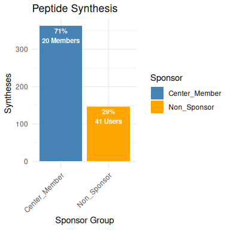

```r
synth.bar <- pep.synth %>%
  mutate(Sponsor_ForPlot = factor(Sponsor_ForPlot, levels = sponsor_order)) %>%
  group_by(Sponsor_ForPlot) %>%
  summarise(Quantity = sum(Quant.To.Present),
            Num_Labs = if_else(first(Sponsor_ForPlot) == "Center_Member",
                               n_distinct(Faculty.Key[Sponsor == "KI_member"]),
                               n_distinct(Faculty.Key)),
            .groups = "drop") %>%
  mutate(Percent = round((Quantity / sum(Quantity)) * 100, 0),
         Lab_Label = if_else(Sponsor_ForPlot == "Center_Member",
                             paste0(Num_Labs, " Members"),
                             paste0(Num_Labs, " Users")),
         Label = paste0(Quantity, "\n\n", Percent, "%\n", Lab_Label)) %>%
  ggplot(aes(x = Sponsor_ForPlot, y = Quantity, fill = Sponsor_ForPlot)) +
  geom_col() +
  geom_text(aes(label = Label),
            vjust = 0.5,
            size = 3,
            fontface = "bold",
            color = "white") +
  scale_fill_manual(values = sponsor_colors) +
  labs(title = "Peptide Synthesis",
       x = "Sponsor Group",
       y = "Syntheses",
       fill = "Sponsor") +
  theme_minimal() +
  theme(legend.position = "right",
        axis.text.x = element_text(angle = 45, hjust = 1))

synth.bar
```

### Peptide synthesis pie chart

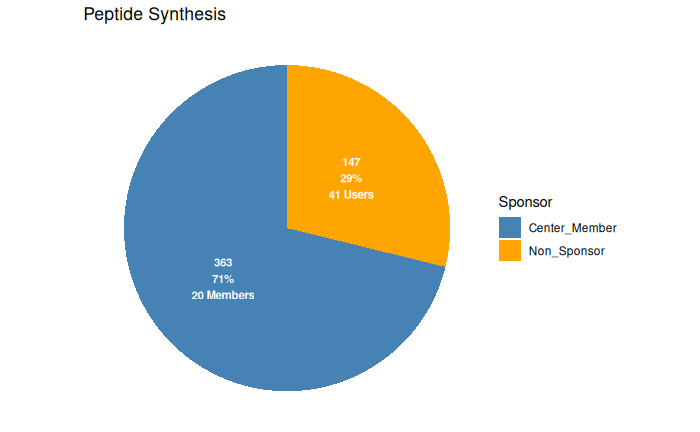

```r
synth.pie <- pep.synth %>%
  mutate(Sponsor_ForPlot = factor(Sponsor_ForPlot, levels = sponsor_order)) %>%
  group_by(Sponsor_ForPlot) %>%
  summarise(Quantity = sum(Quant.To.Present),
            Num_Labs = if_else(first(Sponsor_ForPlot) == "Center_Member",
                               n_distinct(Faculty.Key[Sponsor == "KI_member"]),
                               n_distinct(Faculty.Key)),
            .groups = "drop") %>%
  mutate(Percent = round((Quantity / sum(Quantity)) * 100, 0),
         Lab_Label = if_else(Sponsor_ForPlot == "Center_Member",
                             paste0(Num_Labs, " Members"),
                             paste0(Num_Labs, " Users")),
         Label = paste0(Quantity, "\n", Percent, "%\n", Lab_Label)) %>%
  ggplot(aes(x = "", y = Quantity, fill = Sponsor_ForPlot)) +
  geom_col() +
  geom_text(aes(label = Label),
            position = position_stack(vjust = 0.5),
            size = 3,
            fontface = "bold",
            color = "white") +
  coord_polar("y", start = 0) +
  scale_fill_manual(values = sponsor_colors) +
  labs(title = "Peptide Synthesis",
       fill = "Sponsor") +
  theme_void() +
  theme(legend.position = "right")

synth.pie
```

## Proteomics Data

### Extract the data from the main dataframe

```r
prot <- msbp.final %>% dplyr::filter(Service.Group == "Proteomics") %>%
  dplyr::filter(!stringr::str_detect(Charge.Name, regex("Data Analysis", ignore_case = TRUE))) %>%
  dplyr::filter(!stringr::str_detect(Charge.Name, regex("\\(charge\\)", ignore_case = TRUE))) %>%
  dplyr::filter(!stringr::str_detect(Charge.Name, regex("MALDI", ignore_case = TRUE)))
```

### Check the results

```r
prot %>% dplyr::select(Charge.Name) %>% unique() %>% dim()
```

```
[1] 52  1
```

### Prepare Proteomics bar chart

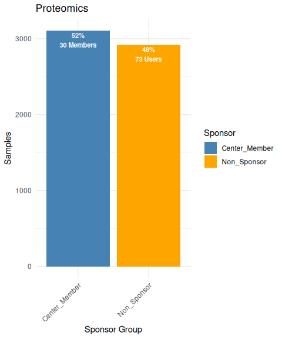

```r
prot.bar <- prot %>%
  mutate(Sponsor_ForPlot = factor(Sponsor_ForPlot, levels = sponsor_order)) %>%
  group_by(Sponsor_ForPlot) %>%
  summarise(Quantity = sum(Quantity),
            Num_Labs = if_else(first(Sponsor_ForPlot) == "Center_Member",
                               n_distinct(Faculty.Key[Sponsor == "KI_member"]),
                               n_distinct(Faculty.Key)),
            .groups = "drop") %>%
  mutate(Percent = round((Quantity / sum(Quantity)) * 100, 0),
         Lab_Label = if_else(Sponsor_ForPlot == "Center_Member",
                             paste0(Num_Labs, " Members"),
                             paste0(Num_Labs, " Users")),
         Label = paste0(Quantity, "\n\n", Percent, "%\n", Lab_Label)) %>%
  ggplot(aes(x = Sponsor_ForPlot, y = Quantity, fill = Sponsor_ForPlot)) +
  geom_col() +
  geom_text(aes(label = Label),
            vjust = 0.5,
            size = 3,
            fontface = "bold",
            color = "white") +
  scale_fill_manual(values = sponsor_colors) +
  labs(title = "Proteomics",
       x = "Sponsor Group",
       y = "Samples",
       fill = "Sponsor") +
  theme_minimal() +
  theme(legend.position = "right",
        axis.text.x = element_text(angle = 45, hjust = 1))

prot.bar
```

### Prepare proteomics pie chart

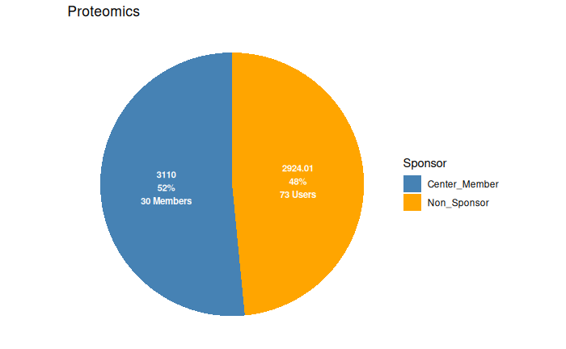

```r
prot.pie <- prot %>%
  mutate(Sponsor_ForPlot = factor(Sponsor_ForPlot, levels = sponsor_order)) %>%
  group_by(Sponsor_ForPlot) %>%
  summarise(Quantity = sum(Quantity),
            Num_Labs = if_else(first(Sponsor_ForPlot) == "Center_Member",
                               n_distinct(Faculty.Key[Sponsor == "KI_member"]),
                               n_distinct(Faculty.Key)),
            .groups = "drop") %>%
  mutate(Percent = round((Quantity / sum(Quantity)) * 100, 0),
         Lab_Label = if_else(Sponsor_ForPlot == "Center_Member",
                             paste0(Num_Labs, " Members"),
                             paste0(Num_Labs, " Users")),
         Label = paste0(Quantity, "\n", Percent, "%\n", Lab_Label)) %>%
  ggplot(aes(x = "", y = Quantity, fill = Sponsor_ForPlot)) +
  geom_col() +
  geom_text(aes(label = Label),
            position = position_stack(vjust = 0.5),
            size = 3,
            fontface = "bold",
            color = "white") +
  coord_polar("y", start = 0) +
  scale_fill_manual(values = sponsor_colors) +
  labs(title = "Proteomics",
       fill = "Sponsor") +
  theme_void() +
  theme(legend.position = "right")

prot.pie
```

## Lipid or Metabolite Profiling

### Extract the data

```r
lip.met <- msbp.final %>% dplyr::filter(Service.Group == "Lipid or Metabolite Profiling")
```

### Check the results

```r
lip.met %>% dplyr::select(Charge.Name) %>% table() %>% as.data.frame()
```

| Charge.Name | Freq |
| --- | --- |
| 2021 lipidomics fee per sample | 20 |
| 2021 Lipidomics fee per sample | 27 |
| 2021 Lipidomics fee per sample (Lipid) | 16 |
| 2021 Lipidomics fee per sample (Other) | 4 |
| 2021 Lipidomics fee per sample (Polar) | 13 |
| 2021 targeted metabolomics fee per sample | 32 |
| 2021 Targeted Metabolomics Fee per sample | 17 |
| 2021 Targeted Metabolomics Fee per sample (Other) | 3 |
| 2021 Targeted Metabolomics Fee per sample (Polar) | 77 |
| 2021 Targeted Metabolomics Fee per sample: Short method | 4 |

[output cut: 16 more lines]

### Prepare the Lipid or Metabolite bar chart

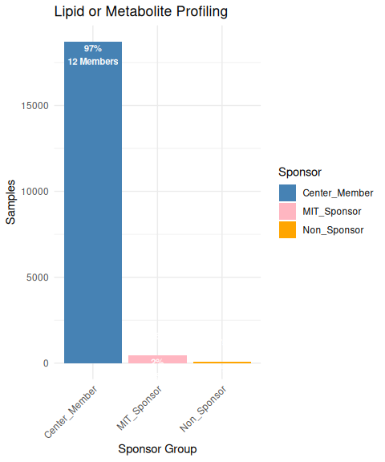

```r
lip.met.bar <- lip.met %>%
  mutate(Sponsor_ForPlot = factor(Sponsor_ForPlot, levels = sponsor_order)) %>%
  group_by(Sponsor_ForPlot) %>%
  summarise(Quantity = sum(Quantity),
            Num_Labs = if_else(first(Sponsor_ForPlot) == "Center_Member",
                               n_distinct(Faculty.Key[Sponsor == "KI_member"]),
                               n_distinct(Faculty.Key)),
            .groups = "drop") %>%
  mutate(Percent = round((Quantity / sum(Quantity)) * 100, 0),
         Lab_Label = if_else(Sponsor_ForPlot == "Center_Member",
                             paste0(Num_Labs, " Members"),
                             paste0(Num_Labs, " Users")),
         Label = paste0(Quantity, "\n\n", Percent, "%\n", Lab_Label)) %>%
  ggplot(aes(x = Sponsor_ForPlot, y = Quantity, fill = Sponsor_ForPlot)) +
  geom_col() +
  geom_text(aes(label = Label),
            vjust = 0.5,
            size = 3,
            fontface = "bold",
            color = "white") +
  scale_fill_manual(values = sponsor_colors) +
  labs(title = "Lipid or Metabolite Profiling",
       x = "Sponsor Group",
       y = "Samples",
       fill = "Sponsor") +
  theme_minimal() +
  theme(legend.position = "right",
        axis.text.x = element_text(angle = 45, hjust = 1))

lip.met.bar
```

### Prepare the Lipid or Metabolite pie chart

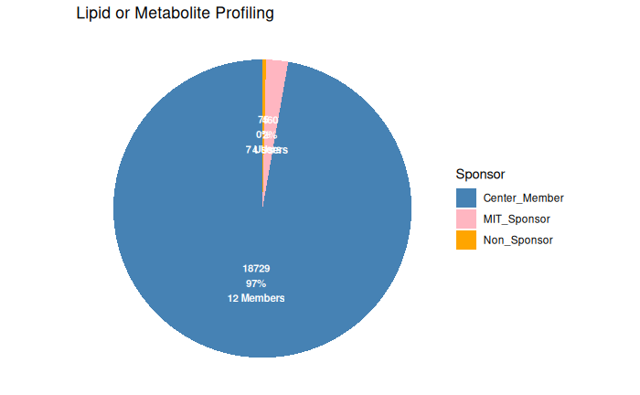

```r
lip.met.pie <- lip.met %>%
  mutate(Sponsor_ForPlot = factor(Sponsor_ForPlot, levels = sponsor_order)) %>%
  group_by(Sponsor_ForPlot) %>%
  summarise(Quantity = sum(Quantity),
            Num_Labs = if_else(first(Sponsor_ForPlot) == "Center_Member",
                               n_distinct(Faculty.Key[Sponsor == "KI_member"]),
                               n_distinct(Faculty.Key)),
            .groups = "drop") %>%
  mutate(Percent = round((Quantity / sum(Quantity)) * 100, 0),
         Lab_Label = if_else(Sponsor_ForPlot == "Center_Member",
                             paste0(Num_Labs, " Members"),
                             paste0(Num_Labs, " Users")),
         Label = paste0(Quantity, "\n", Percent, "%\n", Lab_Label)) %>%
  ggplot(aes(x = "", y = Quantity, fill = Sponsor_ForPlot)) +
  geom_col() +
  geom_text(aes(label = Label),
            position = position_stack(vjust = 0.5),
            size = 3,
            fontface = "bold",
            color = "white") +
  coord_polar("y", start = 0) +
  scale_fill_manual(values = sponsor_colors) +
  labs(title = "Lipid or Metabolite Profiling",
       fill = "Sponsor") +
  theme_void() +
  theme(legend.position = "right")

lip.met.pie
```

## MALDI or HPLC

### Extract the data

```r
maldi <- msbp.final %>% dplyr::filter(Charge.Name %in% c("MALDI additional mode run",
                                                         "MALDI MS run","analytical run",
                                                         "desalting, dye-labeled oligonucleotide or peptide",
                                                         "purification, up to 10 mg",
                                                         "purification, up to 100 mg"))
```

### Check the results

```r
maldi %>% dplyr::select(Charge.Name) %>% table() %>% as.data.frame()
```

| Charge.Name | Freq |
| --- | --- |
| analytical run | 284 |
| desalting, dye-labeled oligonucleotide or peptide | 5 |
| MALDI additional mode run | 9 |
| MALDI MS run | 978 |
| purification, up to 10 mg | 317 |
| purification, up to 100 mg | 217 |

### Prepare the MALDI or HPLC bar chart

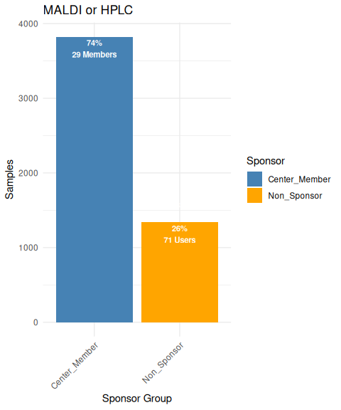

```r
maldi.bar <- maldi %>%
  mutate(Sponsor_ForPlot = factor(Sponsor_ForPlot, levels = sponsor_order)) %>%
  group_by(Sponsor_ForPlot) %>%
  summarise(Quantity = sum(Quantity),
            Num_Labs = if_else(first(Sponsor_ForPlot) == "Center_Member",
                               n_distinct(Faculty.Key[Sponsor == "KI_member"]),
                               n_distinct(Faculty.Key)),
            .groups = "drop") %>%
  mutate(Percent = round((Quantity / sum(Quantity)) * 100, 0),
         Lab_Label = if_else(Sponsor_ForPlot == "Center_Member",
                             paste0(Num_Labs, " Members"),
                             paste0(Num_Labs, " Users")),
         Label = paste0(Quantity, "\n\n", Percent, "%\n", Lab_Label)) %>%
  ggplot(aes(x = Sponsor_ForPlot, y = Quantity, fill = Sponsor_ForPlot)) +
  geom_col() +
  geom_text(aes(label = Label),
            vjust = 0.5,
            size = 3,
            fontface = "bold",
            color = "white") +
  scale_fill_manual(values = sponsor_colors) +
  labs(title = "MALDI or HPLC",
       x = "Sponsor Group",
       y = "Samples",
       fill = "Sponsor") +
  theme_minimal() +
  theme(legend.position = "right",
        axis.text.x = element_text(angle = 45, hjust = 1))

maldi.bar
```

### Prepare the MALDI or HPLC pie chart

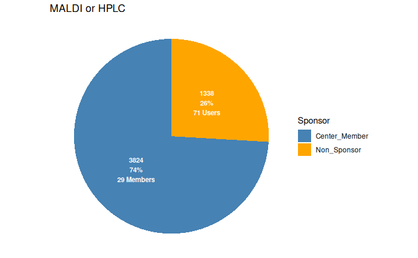

```r
maldi.pie <- maldi %>%
  mutate(Sponsor_ForPlot = factor(Sponsor_ForPlot, levels = sponsor_order)) %>%
  group_by(Sponsor_ForPlot) %>%
  summarise(Quantity = sum(Quantity),
            Num_Labs = if_else(first(Sponsor_ForPlot) == "Center_Member",
                               n_distinct(Faculty.Key[Sponsor == "KI_member"]),
                               n_distinct(Faculty.Key)),
            .groups = "drop") %>%
  mutate(Percent = round((Quantity / sum(Quantity)) * 100, 0),
         Lab_Label = if_else(Sponsor_ForPlot == "Center_Member",
                             paste0(Num_Labs, " Members"),
                             paste0(Num_Labs, " Users")),
         Label = paste0(Quantity, "\n", Percent, "%\n", Lab_Label)) %>%
  ggplot(aes(x = "", y = Quantity, fill = Sponsor_ForPlot)) +
  geom_col() +
  geom_text(aes(label = Label),
            position = position_stack(vjust = 0.5),
            size = 3,
            fontface = "bold",
            color = "white") +
  coord_polar("y", start = 0) +
  scale_fill_manual(values = sponsor_colors) +
  labs(title = "MALDI or HPLC",
       fill = "Sponsor") +
  theme_void() +
  theme(legend.position = "right")

maldi.pie
```

## Time data

### Extract the data from the main dataframe

```r
time <- msbp.final %>% dplyr::filter(Charge.Name %in% c("Instrument Use Only (per hour) (Polar)",
  "Instrument Use Only (per hour) (Lipid)",
  "instrument use only (per hour)",
  "Agilent 1100 HPLC -Daily",
  "Agilent 1100 HPLC -Nucleic Acid Dedicated (Agilent 1100 HPLC) | Friday, February 21",
  "Data Analysis (ID search)",
  "Data Analysis (PTM analysis; for single protein manual verification)",
  "Data Analysis (quantitation analysis; TMT; PRM; LFQ; SILAC)",
  "Data Analysis (small molecules; pk)",
  "Method Development and Data Analysis Time",
  "Method Development and Data Analysis Time (Polar)",
  "Method Development and Data Analysis Time (Porphyrins )",
  "Method development and data analysis WIBR collaborative rate",
  "Training: data analysis & Instrument",
  "Simple Digest",
  "Additional Simple Digest",
  "Medium Complex Digest",
  "Additional Medium Complex Digest",
  "Complex Digest",
  "Additional Complex Digest",
  "Simple Digest- Phosphorylation",
  "Additional Simple Digest- Phosphorylation",
  "Medium Complex Digest- Phosphorylation",
  "Additional Medium Complex Digest- Phosphorylation",
  "Complex Digest- Phosphorylation",
  "Additional Complex Digest- Phosphorylation",
  "TMT6 (IP)",
  "TMT10 (IP)",
  "TMT6 (lysate)",
  "TMT10 (lysate)",
  "TMT16 (lysate)",
  "TMT6 (phospho experiment)",
  "TMT10 (phospho experiment)",
  "TMT16 (phospho experiment)",
  "TMT10 (tyrosine experiment)"))
```

### Subset data for collapse

```r
time.collapse <- time %>% dplyr::filter(Charge.Name %in% c("Data Analysis (ID search)",
                       "Data Analysis (PTM analysis; for single protein manual verification)",
                       "Data Analysis (quantitation analysis; TMT; PRM; LFQ; SILAC)",
                       "Data Analysis (small molecules; pk)","Simple Digest","Additional Simple Digest",
                       "Medium Complex Digest","Additional Medium Complex Digest","Complex Digest",
                       "Additional Complex Digest","Simple Digest- Phosphorylation","Additional Simple Digest- Phosphorylation",
                       "Medium Complex Digest- Phosphorylation","Additional Medium Complex Digest- Phosphorylation",
                       "Complex Digest- Phosphorylation","Additional Complex Digest- Phosphorylation","TMT6 (IP)",
                       "TMT10 (IP)","TMT6 (lysate)","TMT10 (lysate)","TMT16 (lysate)","TMT6 (phospho experiment)",
                       "TMT10 (phospho experiment)","TMT16 (phospho experiment)","TMT10 (tyrosine experiment)"))
```

#### Collapse to one row per Service.ID and set quantity to 1

```r
time.collapsed <- time.collapse %>%
  arrange(Service.ID) %>%
  distinct(Service.ID, .keep_all = TRUE) %>%
  dplyr::mutate(Quantity = 1)
```

#### Check the results

```r
dim(time.collapse)
```

```
[1] 1387   25
```

```r
dim(time.collapsed)
```

```
[1] 824  25
```

```r
summary(time.collapse$Quantity)
```

```
   Min. 1st Qu.  Median    Mean 3rd Qu.    Max.
  0.000   1.000   1.000   2.354   2.000  27.000
```

```r
summary(time.collapsed$Quantity)
```

```
   Min. 1st Qu.  Median    Mean 3rd Qu.    Max.
      1       1       1       1       1       1
```

#### Add Quant.To.Present value of 1.5 for each row in time.collapsed

```r
time.collapsed <- time.collapsed %>% dplyr::mutate(Quant.To.Present = 1.5)
```

#### negate the time.collapsed selection for other adjustments

```r
time.noCollapse <- time %>% dplyr::filter(!Charge.Name %in% c("Data Analysis (ID search)",
                       "Data Analysis (PTM analysis; for single protein manual verification)",
                       "Data Analysis (quantitation analysis; TMT; PRM; LFQ; SILAC)",
                       "Data Analysis (small molecules; pk)","Simple Digest","Additional Simple Digest",
                       "Medium Complex Digest","Additional Medium Complex Digest","Complex Digest",
                       "Additional Complex Digest","Simple Digest- Phosphorylation","Additional Simple Digest- Phosphorylation",
                       "Medium Complex Digest- Phosphorylation","Additional Medium Complex Digest- Phosphorylation",
                       "Complex Digest- Phosphorylation","Additional Complex Digest- Phosphorylation","TMT6 (IP)",
                       "TMT10 (IP)","TMT6 (lysate)","TMT10 (lysate)","TMT16 (lysate)","TMT6 (phospho experiment)",
                       "TMT10 (phospho experiment)","TMT16 (phospho experiment)","TMT10 (tyrosine experiment)"))
```

#### Adjust the quantity in this set

```r
time.noCollapse <- time.noCollapse%>% dplyr::mutate(
  Quant.To.Present = dplyr::case_when(
    Charge.Name == "Agilent 1100 HPLC -Daily" ~ Quantity * 8,
    TRUE ~ Quantity  # default case
  )
)
```

#### Recombine the data

```r
time <- rbind(time.collapsed,time.noCollapse)
```

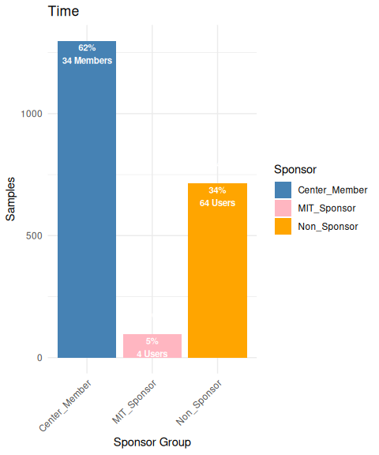

```r
time.bar <- time %>%
  mutate(Sponsor_ForPlot = factor(Sponsor_ForPlot, levels = sponsor_order)) %>%
  group_by(Sponsor_ForPlot) %>%
  summarise(Quantity = sum(Quant.To.Present),
            Num_Labs = if_else(first(Sponsor_ForPlot) == "Center_Member",
                               n_distinct(Faculty.Key[Sponsor == "KI_member"]),
                               n_distinct(Faculty.Key)),
            .groups = "drop") %>%
  mutate(Percent = round((Quantity / sum(Quantity)) * 100, 0),
         Lab_Label = if_else(Sponsor_ForPlot == "Center_Member",
                             paste0(Num_Labs, " Members"),
                             paste0(Num_Labs, " Users")),
         Label = paste0(Quantity, "\n\n", Percent, "%\n", Lab_Label)) %>%
  ggplot(aes(x = Sponsor_ForPlot, y = Quantity, fill = Sponsor_ForPlot)) +
  geom_col() +
  geom_text(aes(label = Label),
            vjust = 0.5,
            size = 3,
            fontface = "bold",
            color = "white") +
  scale_fill_manual(values = sponsor_colors) +
  labs(title = "Time",
       x = "Sponsor Group",
       y = "Samples",
       fill = "Sponsor") +
  theme_minimal() +
  theme(legend.position = "right",
        axis.text.x = element_text(angle = 45, hjust = 1))

time.bar
```

### Prepare the time pie chart

[figure not shown]

```r
time.pie <- time %>%
  mutate(Sponsor_ForPlot = factor(Sponsor_ForPlot, levels = sponsor_order)) %>%
  group_by(Sponsor_ForPlot) %>%
  summarise(Quantity = sum(Quant.To.Present),
            Num_Labs = if_else(first(Sponsor_ForPlot) == "Center_Member",
                               n_distinct(Faculty.Key[Sponsor == "KI_member"]),
                               n_distinct(Faculty.Key)),
            .groups = "drop") %>%
  mutate(Percent = round((Quantity / sum(Quantity)) * 100, 0),
         Lab_Label = if_else(Sponsor_ForPlot == "Center_Member",
                             paste0(Num_Labs, " Members"),
                             paste0(Num_Labs, " Users")),
         Label = paste0(Quantity, "\n", Percent, "%\n", Lab_Label)) %>%
  ggplot(aes(x = "", y = Quantity, fill = Sponsor_ForPlot)) +
  geom_col() +
  geom_text(aes(label = Label),
            position = position_stack(vjust = 0.5),
            size = 3,
            fontface = "bold",
            color = "white") +
  coord_polar("y", start = 0) +
  scale_fill_manual(values = sponsor_colors) +
  labs(title = "Time",
       fill = "Sponsor") +
  theme_void() +
  theme(legend.position = "right")

maldi.pie
```

# Plot the pie charts figure

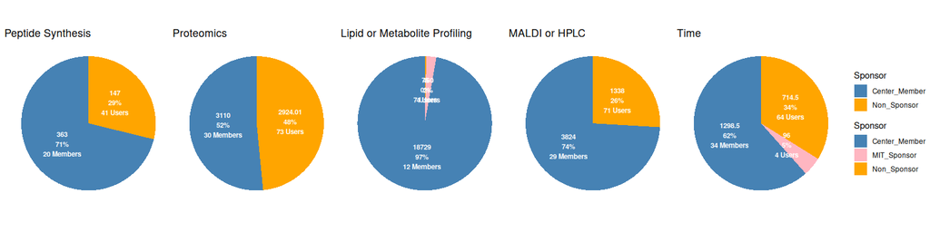

```r
synth.pie + prot.pie + lip.met.pie + maldi.pie + time.pie + plot_layout(ncol = 5, guides = "collect")
```

```r
combo.pie <- synth.pie + prot.pie + lip.met.pie + maldi.pie + time.pie + plot_layout(ncol = 5, guides = "collect")
ggsave("figures/MSBP_combo.pie.pdf",
       plot = combo.pie,
       dpi = 150,
       width = 16,
       height = 4,
       units = "in")
```

# Write annotated output file

```r
write.xlsx(msbp.final,"msbp.final.xlsx")
```

# write session info

Capturing information about the R session helps document your work

```r
sessionInfo()
writeLines(capture.output(sessionInfo()), "msbp_processing_sessionInfo.txt")
```